# Campus Food Insights: Student Eating Habits, Satisfaction, and Data Mining Report

Data Mining and Analysis Lab Project

November 11, 2026

# 1 Introduction

Understanding how university students eat on campus helps campus administrators, hostel mess committees, and food vendors improve food quality, hygiene, affordability, and outlet availability. In this **Campus Food Insights** project, we analyze a Google Form student survey covering campus outlet preferences, daily meals eaten at campus outlets, meal skipping, monthly extra spending, outside food ordering, overall satisfaction, decision factors, and wanted improvements.

The goal is simple and practical: clean the raw survey answers carefully, explore overall patterns and group differences using simple statistical checks (cross-tables, percentages, Pearson correlations, and chi-square tests), answer focused questions that emerge from the data, apply two data-mining techniques (**association rules** and a **decision tree**), and package everything into an interactive **Shiny dashboard** (`app/app.R`) and this final HTML report.

# 2 Data Collection

The raw dataset (`data/dmaProjectdata.csv`) contains **88 student responses** across **20 columns**, collected via Google Forms on `10/11/2026` between `15:15:14` and `15:53:33` (a roughly 38-minute window).

Important sampling characteristics of who answered:

- **Year of study:** 66 students (75%) are in **3rd Year**, 12 (13.6%) in 1st Year, and 10 (11.4%) in 2nd Year.
- **Residence:** 84 (95.5%) live in the **Hostel**, and only 4 (4.5%) are Day Scholars.
- **Gender:** 56 (63.6%) are Male and 32 (36.4%) are Female.
- **Rare groups (< 8 students):** Day Scholars (4), Vegans (1), and Cash payers (2) each have fewer than 8 responses. Per project rules, we report **“too few responses”** rather than making subgroup claims for them.

# 3 Cleaning

All cleaning steps live in `R/01_clean.R` and keep the raw CSV untouched. Key steps and quality checks:

1. **Duplicate check:** 0 exact duplicate rows and 0 duplicate answer rows (excluding `Timestamp`).
2. **Empty columns dropped (6 columns, 100% NA):** `Untitled Question`, all four dining facility-rating columns (*Infrastructure and Seating*, *Staff Friendliness*, *Operating Hours/Availability*, *Waste Management/Cleanliness*), and the *Nutrition Information* question were completely empty (`0 / 88` responses) and were dropped.
3. **Messy text-to-number fixes (4 distinct rows fixed, 0 NAs left):**
   - `meals_per_day` (2 rows): `"1-2 meals"` parsed to `1` (conservative lower bound via `readr::parse_number()`) and `"1 times"` parsed to `1`.
   - `spend` (2 rows): stripped `"Rs."` prefix and parsed `"Rs. 2,000/-"` to `2000` and `"around 1000"` to `1000`.
   - `outside_orders` (2 rows): converted `"twice a week"` to `2` and parsed `"1 times"` to `1`.
4. **Multi-select splitting:** Split `outlets` (`9` options), `factors` (`11` options), and `improvements` (`11` options) into `31` binary `0/1` columns using `stringr::str_detect(..., fixed())`, with `0` count mismatches across all `88` rows.
5. **Derived helper columns & ordered factors:** Created ordered factors for `year` and `spend_band` (`Low (<= Rs 1,000)`, `Medium (Rs 1,001-2,000)`, `High (> Rs 2,000)`), plus binary flags:
   - `satisfied`: rating `>= 4` (24 students, 27.3%).
   - `skips_breakfast`: skips Breakfast most often (62 students, 70.5%).
   - `heavy_outside`: orders outside `>= 2` times/week (17 students, 19.3%), separating the top fifth from the 80.7% who order `0` or `1` time per week.

Table 1: Data Quality and Cleaning Summary

| metric | value |
| --- | --- |
| Raw rows | 88 |
| Raw columns | 20 |
| Empty columns dropped | 6 |
| Exact duplicate rows (all cols) | 0 |
| Duplicate rows (excluding Timestamp) | 0 |
| Rows fixed in meals_per_day | 2 |
| Rows fixed in spend | 2 |
| Rows fixed in outside_orders | 2 |
| Distinct rows with text-to-number fixes | 4 |
| Clean rows saved | 88 |
| Clean columns saved | 49 |

# 4 Overall Analysis

Before exploring subgroups, we inspect the big-picture metrics across all 88 respondents (`R/02_overall.R`):

- **Monthly extra food spend (excluding mess fees):** Mean = **Rs 1753.41**, Median = **Rs 1500** (range Rs 500 to Rs 4000). Half of students (51.1%, 45) fall in the Medium band (`Rs 1,001-2,000`), 25% (22) spend `<= Rs 1,000`, and 23.9% (21) spend `> Rs 2,000`.
- **Meals & outside ordering:** Students eat an average of **0.94** campus outlet meals/day (median 1) and order outside food **0.93** times/week (median 1).
- **Diet & payment:** Vegetarian (39, 44.3%) and Non-Vegetarian (39, 44.3%) are equal in size, followed by Eggetarian (9, 10.2%) and Vegan (1, too few responses). UPI/QR Code accounts for **97.7%** (86 of 88).
- **Overall satisfaction:** Mean = **3.01 / 5**, Median = **3**. Nearly half (47.7%, 42) chose neutral `3`, 22 (25%) are dissatisfied (`1` or `2`), and only **24 (27.3%)** are satisfied (`4` or `5`).
- **Meal skipping:** **70.5%** (62 of 88) skip **Breakfast** most often, far ahead of Lunch (13.6%) and Evening Snack (9.1%).

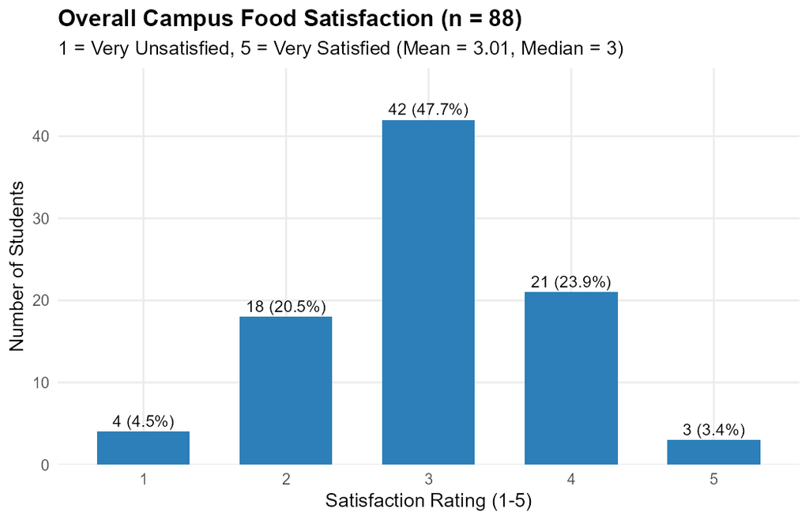

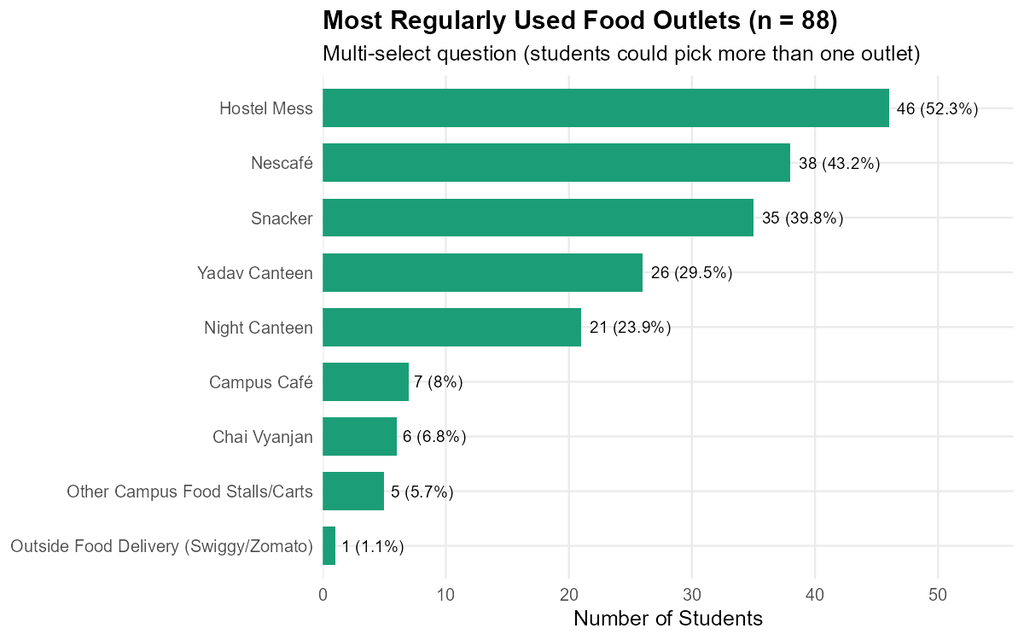

Table 2: Factors Rated Important When Choosing a Food Outlet

| Rank | Factor | Count | Pct (%) |
| --- | --- | --- | --- |
| 1 | Food Quality | 48 | 54.5 |
| 2 | Price/Affordability | 45 | 51.1 |
| 3 | Portion Size | 43 | 48.9 |
| 4 | Hygiene/Cleanliness | 42 | 47.7 |
| 5 | Taste | 39 | 44.3 |
| 6 | Healthy/Nutritious Options | 9 | 10.2 |
| 7 | Location/Convenience | 8 | 9.1 |
| 8 | Variety of Food | 7 | 8.0 |
| 9 | Waiting Time | 6 | 6.8 |
| 10 | Availability | 5 | 5.7 |
| 11 | Seating/Ambience | 5 | 5.7 |

Table 3: Biggest Wanted Improvements in Campus Food

| Rank | Improvement | Count | Pct (%) |
| --- | --- | --- | --- |
| 1 | Better Hygiene/Cleanliness | 46 | 52.3 |
| 2 | Better Food Quality | 44 | 50.0 |
| 3 | Lower Prices | 37 | 42.0 |
| 4 | Larger Portions | 21 | 23.9 |
| 5 | Better Taste | 20 | 22.7 |
| 6 | More Healthy/Nutritious Options | 10 | 11.4 |
| 7 | More Variety | 10 | 11.4 |
| 8 | Faster Service | 9 | 10.2 |
| 9 | Better Seating/Ambience | 8 | 9.1 |
| 10 | Better Availability | 6 | 6.8 |
| 11 | More Food Outlets | 6 | 6.8 |

# 5 EDA Facts

Using `R/03_eda.R`, we compared satisfaction, spend, breakfast skipping, and outside ordering across Year, Gender, Diet (excluding Vegan `n = 1`), Spend Band, and each outlet with at least 8 users (excluding Campus Café `n = 7`, Chai Vyanjan `n = 6`, Other Stalls `n = 5`, and Outside Delivery `n = 1`).

## 5.1 Statistically Supported Facts (Chi-Square `p < 0.05`)

1. **Spend Band vs. Satisfaction (`p = 0.0123`):** High spenders (`> Rs 2,000`) are much more likely to be satisfied (52.4%, 11/21) than Medium (20%, 9/45) and Low (18.2%, 4/22) spenders.
2. **Nescafé Usage vs. Satisfaction (`p = 0.0456`):** Nescafé users (`n = 38`) are more than twice as likely to be satisfied (39.5%, 15/38) as non-users (18%, 9/50).
3. **Diet vs. Lower Prices Demand (`p = 0.0206`):** Vegetarians ask for Lower Prices significantly more often (56.4%, 22/39) than Non-Vegetarians (25.6%, 10/39) and Eggetarians (44.4%, 4/9).

## 5.2 Noticeable Patterns Only (Not Confirmed at `p < 0.05` — May Be Luck)

- **Yadav Canteen & Breakfast Skipping (`p = 0.0505`):** Yadav Canteen users skip breakfast less often (53.8% vs 77.4% for non-users).
- **Diet & Food Channels:** Vegetarians show higher heavy outside ordering (30.8% vs 10.3% Non-Veg, `p = 0.0648`), higher Hostel Mess use (66.7% vs 41%, `p = 0.077`), and lower Night Canteen use (12.8% vs 33.3%, `p = 0.1072`).
- **Night Canteen & Breakfast Skipping (`p = 0.1382`):** 85.7% of Night Canteen users skip breakfast vs 65.7% of non-users (not statistically supported).
- **Gender & Linear Correlations:** Male and Female students look nearly identical across all outcomes (`p >= 0.4638`), and all pairwise Pearson correlations between numeric columns are weak (`|r| <= 0.132`, all `p >= 0.2215`).

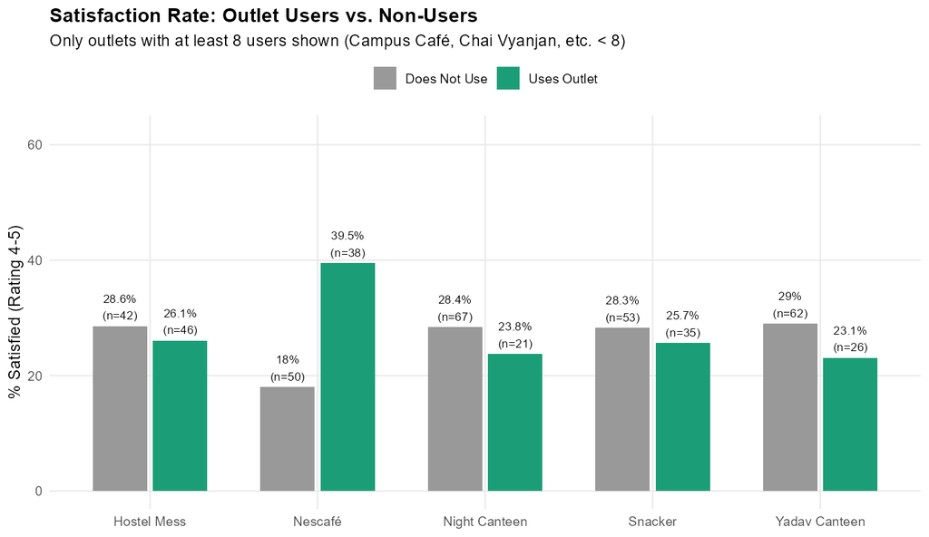

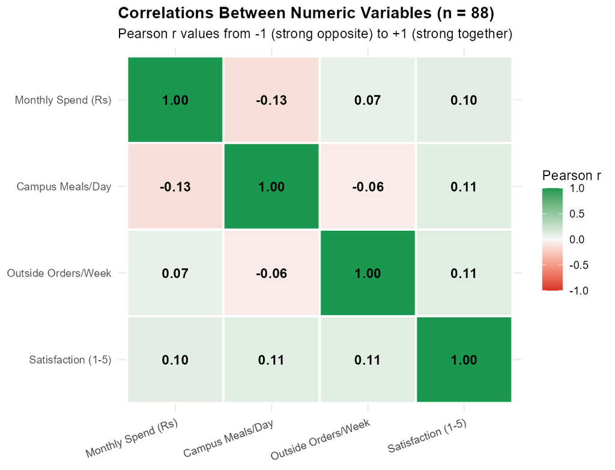

# 6 Questions and Answers

Five focused research questions were drawn directly from the strongest Phase 2 and Phase 3 findings (`R/04_questions.R`):

### Q1. Why are high spenders (> Rs 2,000/month) much more satisfied than low or medium spenders?

High spenders (`n = 21`) eat fewer campus outlet meals per day (0.71 vs 1.01), order outside slightly more (1.1 vs 0.88/week; 28.6% heavy vs 16.4%), and use Nescafé more (57.1% vs 38.8%) while using Yadav Canteen less (19% vs 32.8%). None of those single item gaps reaches `p < 0.05` (`p = 0.2195` to 1), and high spenders still ask for Better Quality (57.1%), Better Hygiene (52.4%), and Lower Prices (52.4%). Higher budgets appear to buy flexibility rather than eliminating complaints, though the survey did not record *which* exact items high spenders buy.

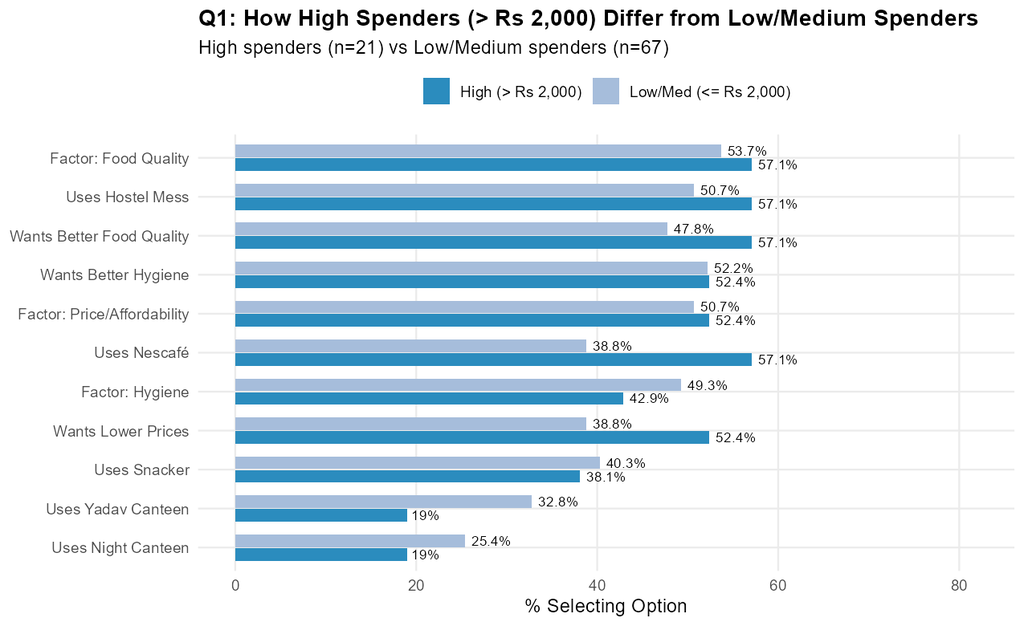

### Q2. What sets Nescafé users apart from non-users, and does using Nescafé explain their higher satisfaction?

Nescafé users (`n = 38`) pick more outlets overall (2.58 vs 1.74), spend slightly more (Rs 1879 vs Rs 1658), and show higher satisfaction within **every** spend band (30% vs 8.3% in Low, 25% vs 17.2% in Medium, and 66.7% vs 33.3% in High). Still, their improvement requests match non-users (50% Hygiene, 50% Quality, 50% Lower Prices). Because the survey measured only overall campus satisfaction rather than per-outlet ratings, we cannot prove Nescafé directly caused the higher rating.

### Q3. Who skips breakfast most often, and how is skipping breakfast linked to outlet choices?

Breakfast skipping (70.5%) cuts evenly across Year, Gender, and Diet (`p >= 0.7516`). The main contrast is outlet choice: only 22.6% of breakfast skippers use Yadav Canteen vs 46.2% of non-skippers (`p = 0.0505`), while Night Canteen leans higher among skippers (29% vs 11.5%, `p = 0.1382`), and skippers are twice as likely to eat `0` campus outlet meals per day (30.6% vs 15.4%). Sleep hours and class schedules were not collected, so the root cause cannot be verified.

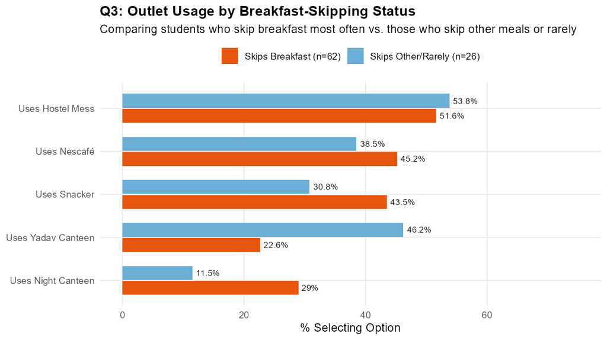

### Q4. Do Vegetarian and Non-Vegetarian students rely on different food channels or want different improvements?

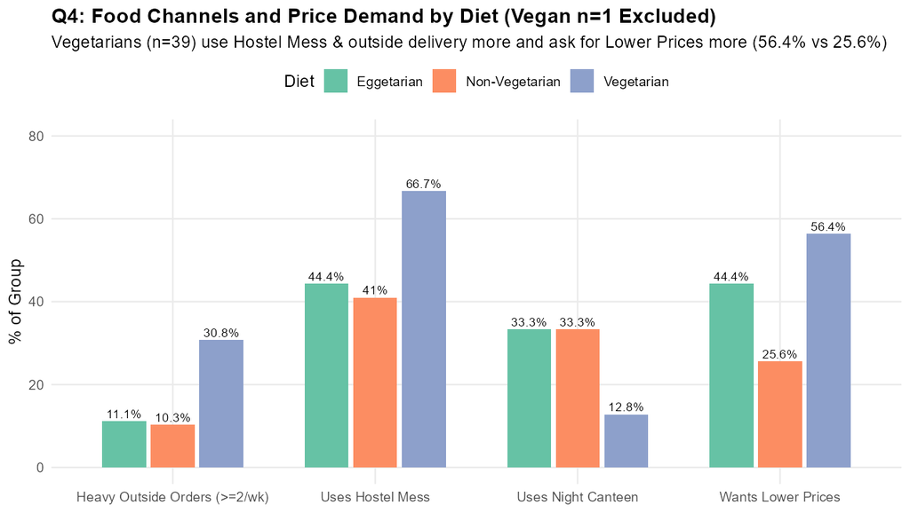

### Q5. Do dissatisfied students ask for different improvements than neutral or satisfied students?

No—improvement demands are campus-wide. Across Dissatisfied (`1-2`, `n = 22`), Neutral (`3`, `n = 42`), and Satisfied (`4-5`, `n = 24`) students, nearly half in every tier ask for Better Hygiene (54.5%, 52.4%, 50%; `p = 0.9534`), Better Food Quality (45.5%, 50%, 54.2%; `p = 0.8401`), and Lower Prices (45.5%, 38.1%, 45.8%; `p = 0.7729`). Because the four facility-rating columns were completely empty, the survey cannot tell which specific physical facility aspect drove low satisfaction.

# 7 Data Mining Results

## 7.1 Association Rules (`arules / apriori`)

Using `support >= 0.14` (`>= 13` students), `confidence >= 0.65`, and `lift > 1.15`, we found **23 non-redundant rules**. Top rules highlight clear patterns of complaints and habits:

- `{Improve: Better Food Quality,Improve: Lower Prices} => {Outlet: Nescafé}` (`count = 13`, `conf = 0.722`, `lift = 1.673`)
- `{Improve: Better Taste} => {Factor: Hygiene/Cleanliness}` (`count = 14`, `conf = 0.7`, `lift = 1.467`)
- `{Improve: Better Taste} => {Outlet: Hostel Mess}` (`count = 14`, `conf = 0.7`, `lift = 1.339`)
- `{Factor: Price/Affordability,Improve: Lower Prices} => {Outlet: Hostel Mess}` (`count = 13`, `conf = 0.65`, `lift = 1.243`)
- `{Outlet: Night Canteen} => {Flag: Skips Breakfast}` (`count = 18`, `conf = 0.857`, `lift = 1.217`)

Table 4: Top 10 Non-Redundant Association Rules (Sorted by Lift)

| rule_id | rules | count | support | confidence | lift |
| --- | --- | --- | --- | --- | --- |
| 1 | {Improve: Better Food Quality,Improve: Lower Prices} => {Outlet: Nescafé} | 13 | 0.148 | 0.722 | 1.673 |
| 2 | {Outlet: Nescafé,Improve: Better Food Quality} => {Improve: Lower Prices} | 13 | 0.148 | 0.684 | 1.627 |
| 3 | {Improve: Better Taste} => {Factor: Hygiene/Cleanliness} | 14 | 0.159 | 0.700 | 1.467 |
| 4 | {Outlet: Nescafé,Improve: Lower Prices} => {Improve: Better Food Quality} | 13 | 0.148 | 0.684 | 1.368 |
| 5 | {Improve: Better Taste} => {Outlet: Hostel Mess} | 14 | 0.159 | 0.700 | 1.339 |
| 6 | {Factor: Portion Size,Improve: Better Hygiene/Cleanliness} => {Outlet: Hostel Mess} | 14 | 0.159 | 0.700 | 1.339 |
| 7 | {Improve: Better Food Quality,Improve: Lower Prices} => {Factor: Food Quality} | 13 | 0.148 | 0.722 | 1.324 |
| 8 | {Factor: Food Quality,Factor: Taste} => {Improve: Better Food Quality} | 13 | 0.148 | 0.650 | 1.300 |
| 9 | {Factor: Portion Size,Improve: Lower Prices} => {Factor: Food Quality} | 14 | 0.159 | 0.700 | 1.283 |
| 10 | {Outlet: Nescafé,Improve: Better Food Quality} => {Factor: Food Quality} | 13 | 0.148 | 0.684 | 1.254 |

## 7.2 Decision Tree (`rpart`)

Predicting `satisfied` (`rating >= 4`), the majority-class baseline (`Not_Satisfied`) is **72.7%**. With 10-fold cross-validation (`cp = 0.0625`), CV accuracy is **73.9%** (in-sample accuracy = 79.5%).

In plain language: first, the tree splits at monthly spend `< Rs 2,250`, where 80.6% of the 67 lower/medium spenders are not satisfied. Among the 21 students spending `>= Rs 2,250`, satisfaction splits on whether Hygiene/Cleanliness is a top decision factor: high spenders who prioritize Hygiene (`n = 9`) are still 77.8% unsatisfied, whereas high spenders who do not flag Hygiene (`n = 12`) are 75% satisfied.

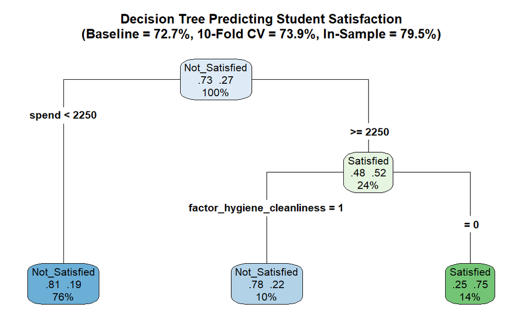

# 8 Dashboard Description

The interactive dashboard (`app/app.R`) loads precomputed results from `outputs/` for fast startup and provides **Year, Diet, and Gender** sidebar filters that apply across all seven tabs:

1. **Overview:** Live `n = X` KPI cards and `plotly` bars for satisfaction, outlets, factors, and improvements.
2. **EDA Facts:** Interactive group comparison selector (flagging groups `< 8` in grey), live correlation heatmap, and searchable chi-square test table.
3. **Questions & Answers:** Dropdown for Q1–Q5 with triggering facts, plain-language summaries, and live filtered `plotly` charts.
4. **Association Rules:** Interactive Lift vs. Confidence bubble chart and `DT` table showing live match counts inside the active filter.
5. **Decision Tree:** `rpart.plot` visual, live leaf satisfaction bars, and baseline vs. CV accuracy summary.
6. **Recommendations:** Actionable takeaways for administration, vendors, and students alongside live filtered priority percentages.
7. **Data:** Searchable `DT` table of filtered records with one-click CSV download.

Every view prints `n = X` and displays an automatic warning banner whenever fewer than `10` students remain.

# 9 Recommendations

# 10 Limitations

- **Small sample size (`n = 88`):** Reduces statistical power for detecting modest differences and leaves Day Scholars (4), Vegans (1), Cash payers (2), and four smaller outlets (`<= 7` users) with too few responses for valid subgroup claims.
- **Biased sample composition:** 75% of respondents are 3rd-year students, 95.5% live in hostels, and 63.6% are male—all collected within a single 38-minute burst—so findings mostly describe 3rd-year hostel residents.
- **Self-reported estimates:** Monthly spending (Rs 500–4000), meals per day, and weekly outside orders rely on student recall and rough text entries (e.g., `"1-2 meals"`, `"around 1000"`).
- **Empty facility-rating and nutrition columns:** All four dining facility ratings (Infrastructure/Seating, Staff Friendliness, Operating Hours, Waste Management/Cleanliness) and the nutrition question had `0 / 88` non-missing answers and had to be excluded.

# 11 Conclusion

Across 88 surveyed students, overall campus food satisfaction is lukewarm (mean = 3.01 / 5, only 27.3% satisfied), 70.5% skip breakfast most often, and UPI/QR Code payments are nearly universal (97.7%). Statistical tests and data mining reinforce a consistent story: students with larger monthly budgets (`> Rs 2,000`) and Nescafé users report higher satisfaction, yet demands for **Better Hygiene (52.3%)**, **Better Food Quality (50%)**, and **Lower Prices (42% — especially 56.4% among Vegetarians)** span the entire campus. Focusing first on hygiene enforcement, mess food quality, vegetarian affordability, and quick breakfast availability directly addresses the biggest evidence-backed gaps.